# STAT 218 Final Project

2024-12-05

# How Can We Better Assess Those In Need?

## Mental Health Triage for Serious Mental Illness and Emotional Disturbance via SVM and RF Machine Learning

```r
CLD <- read.csv("CLD.csv")
```

```r
# Take the random sample of a manageable size

sample_size = 10000
set.seed(77)
CLD_sample <- sample(1:nrow(CLD),
                     size = sample_size)

CLD_sampled_data <- CLD[CLD_sample, ]
```

# Introduction

The modern mental health crisis in the United States has taken a toll on all individuals across the country. With more people suffering from psychological disorders than ever before in the United States, Mental health care is at a premium. While inpatient and outpatient mental health facilities have undoubtedly achieved successful diagnosis and treatment of a range of disorders, clinical resources– including psychiatrists, psychologists, and social workers– are spread thin and overworked (Modi et al., 2022). With expanding networks and growing needs in United States mental health care, effective and precise triage of individuals with mental illness is of paramount importance in order to deliver care to those who need it most. The present analysis seeks to understand if machine learning may be applied to better triage those with severe mental health conditions in need of service. The following questions are assessed herein: Can a machine learning approach effectively triage individuals suffering from Serious Mental Illnesses? Moreover, What variables are most useful in predicting deleterious mental health outcomes? To investigate these questions, I began my investigation at the Substance Abuse and Mental Health Service Administration (SAMHSA) website https://www.samhsa.gov/. SAMHSA performs nationally representative surveys of mental health services, symptoms, and substance abuse in the United States on an annual basis. The administration publishes five nationwide surveys per year, three of which focus on mental health and substance abuse services in the United States to measure the effectiveness of clinics and public/private funding, while the other two–the Mental Health Client-Level Data (MH-CLD) and The National Survey on Drug Use and Health (NSDUH)– focus on individual health indicators in such facilities. In an effort to effectively work with particular demographic and general diagnostic information with a manageable range, I chose to use the MH-CLD, containing 68 survey questions, rather than the NSDUH, which contains over 200 items many of which concern the specifics of drug usage, which may be out of the scope of the current research question. The MH-CLD releases yearly public-use files (PUFs), treated with confidentiality protections. These PUFs contain information about clients who have received mental health treatment services, including demographics, national outcome measures, and substance use characteristics. The codebook for the data can be obtained here: https://www.samhsa.gov/data/data-we-collect/mh-cld/datafiles. In this way, the MH-CLD represents the most user-friendly sample of nationally collected data publicly available. For the present analysis, my chosen target variable for prediction will be SMI/SED status, which is coded in the data as SMISED. This variable indicates whether an individual client has had a serious mental illness (SMI) or serious emotional disturbance (SED) using the NIMH definition. According to the NIMH, an SMI represents a subset of Any Mental Illness (AMI) where a mental, behavioral, or emotional disorder results in serious functional impairment, which substantially interferes with or limits one or more major life activities. In particular, the burden of mental illnesses is especially concentrated among those who experience disability due to SMI (NIMH). Childhood SED is defined as the presence of a diagnosable mental, behavioral, or emotional disorder that results in functional impairment that substantially interferes with or limits the child’s role or functioning in family, school, or community activities (SAMHSA, 1993). According to these definitions, SED may be thought of as the childhood equivalent of SMI, due to the limitations of many diagnoses for minors in the United States. Those with SMI/SED in the present data set represent a group that ought to receive more individualized and effective care. An effective machine learning algorithm would fit into a stepped care model which seeks to prioritize a community’s finite mental health resources to those who may be struggling the most (Ho et al., 2016). Moreover, if we can understand what demographic and diagnostic factors contribute to particularly debilitating mental health outcomes, we may better implement early childhood interventions for those in at-risk communities. While this sample represents those who have received either inpatient or outpatient care from a mental health provider, these individuals can provide the grounds for those in the real world who have yet to receive or seek help.

# Exploratory Analysis

Before any predictive work, let’s use the codebook to recode the data and look at the distribution of SMI/SED.

### Table 1

```r
CLD_sampled_data$SMISED <- recode(CLD_sampled_data$SMISED, `1` = "SMI", `2` ="SED and/or at risk for SED", `3` = "No SMI", `-9` = "N/A" )

CLD_sampled_data$SMISED <- ifelse(CLD_sampled_data$SMISED == "N/A", NA, CLD_sampled_data$SMISED)

CLD_sampled_data$SMISED <- as.factor(CLD_sampled_data$SMISED)

CLD_sampled_data %>%
  group_by(SMISED) %>%
  count()
```

```
## # A tibble: 4 × 2
## # Groups:   SMISED [4]
##   SMISED                         n
##   <fct>                      <int>
## 1 No SMI                      2450
## 2 SED and/or at risk for SED  1828
## 3 SMI                         5118
## 4 <NA>                         604
```

In table 1, we see our four responses for the SMI/SED question. Respondents were asked whether they had ever had a serious mental illness (SMI) or serious emotional disturbance (SED) using the NIMH definition listed above. Just over half of the respondents (51.18 %) had experienced a Serious Mental Illness, while approximately a quarter (24.50 %) had experienced no Serious Mental Illness, followed by (18.28 %) who had or were at risk for Serious emotional Disturbance.

As we can see, 604 of these respondents failed to complete this question. To further understand the likely distribution of this variable, lets impute these missing responses based on the results of a random forest.

```r
# impute N/As

imputed_CLD <- mice(CLD_sampled_data,
                         method = "rf",
                         seed = 1)
completed_CLD_sample <- complete(imputed_CLD)
```

Lets now look at few variables that might show interactions with SMI/SED. First, because of the age-based implications of the diagnosis, lets look at the distribution of SMI/SED by age.

### Figure 1

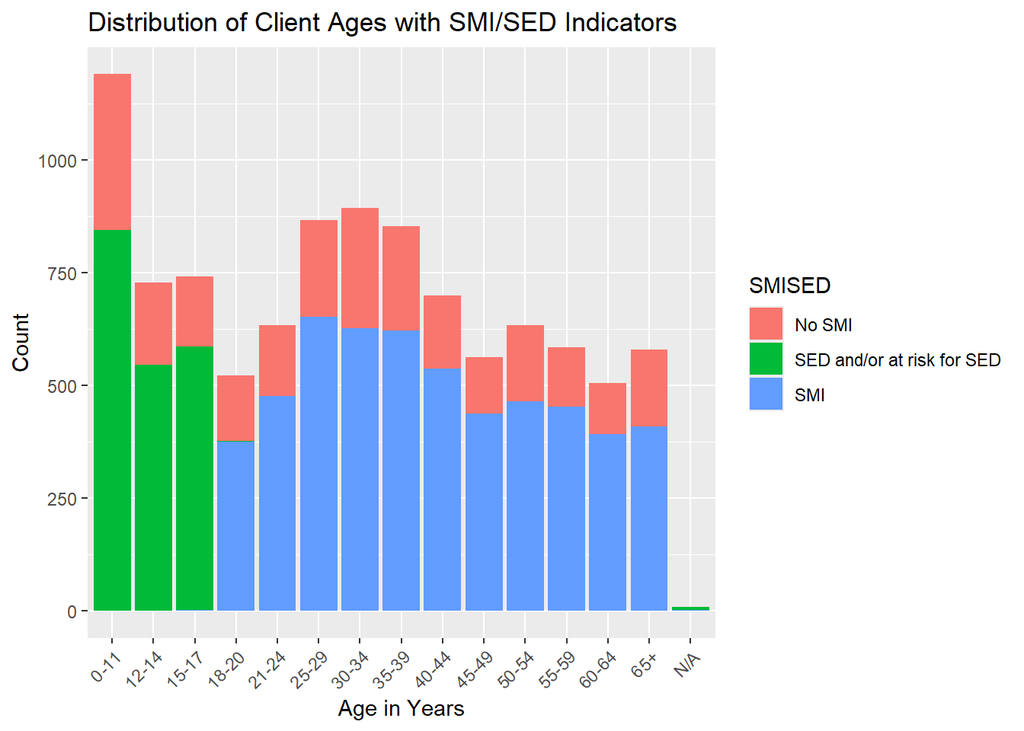

```r
completed_CLD_sample$AGE <- recode(completed_CLD_sample$AGE, `1` = "0-11", `2` = "12-14", `3` = "15-17", `4` = "18-20", `5` = "21-24", `6` = "25-29", `7` = "30-34", `8` = "35-39", `9` = "40-44", `10` = "45-49", `11` = "50-54", `12` = "55-59", `13` = "60-64", `14` = "65+", `-9` = "N/A")

completed_CLD_sample %>%
  ggplot() + theme(axis.text.x = element_text(angle = 45, hjust = 1))+
  geom_bar(aes(x = AGE, fill = SMISED))+ xlab("Age in Years") + ylab("Count") + ggtitle("Distribution of Client Ages with SMI/SED Indicators")
```

Here we can see the age-dependent diagnoses of SED versus SMI. For our purposes of predicting serious mental illness in an attempt to triage debilitating disorders for all ages, it would be advantageous to collapse these two diagnoses into one “SMI/SED” category.

```r
# re-code again to combine SED and SMI
completed_CLD_sample$SMISED <- recode(completed_CLD_sample$SMISED, "SMI" = "SMI/SED", "SED and/or at risk for SED" = "SMI/SED",  "No SMI" = "No SMI or SED" )
```

### Figure 2

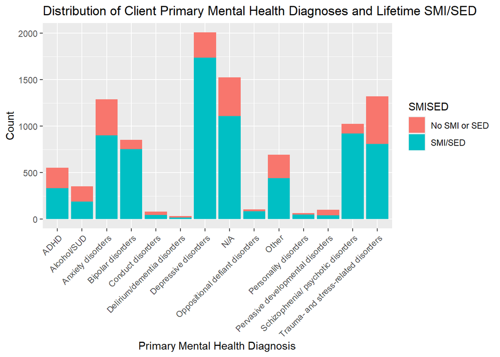

```r
# relationsip between primary mental health diagnosis and SMI outcome
completed_CLD_sample$MH1 <- recode(completed_CLD_sample$MH1, `1` = "Trauma- and stress-related disorders", `2` = "Anxiety disorders", `3` = "ADHD", `4` = "Conduct disorders", `5` = "Delirium/dementia disorders", `6` = "Bipolar disorders", `7` = "Depressive disorders", `8` = "Oppositional defiant disorders", `9` = "Pervasive developmental disorders", `10` = "Personality disorders", `11` = "Schizophrenia/ psychotic disorders", `12` = "Alcohol/SUD", `13` = "Other", `-9` = "N/A")

completed_CLD_sample %>%
  ggplot() +
  geom_bar(aes(x = MH1, fill = SMISED)) +
  theme(axis.text.x = element_text(angle = 45, hjust = 1))+
  xlab("Primary Mental Health Diagnosis") + ylab("Count") + ggtitle("Distribution of Client Primary Mental Health Diagnoses and Lifetime SMI/SED")
```

Figure 2 above demonstrates both the distribution of Primary Mental Health Diagnoses and the percentage of those receiving a certain diagnosis who are considered to have Serious Mental Illness or Severe Emotional Disturbance. An acute diagnosis such as schizophrenia is seen to effect just about 1000 individuals of 10,000 in the sample, but almost all are considered to be SMI/SED. On the other hand trauma and stress-related disorders effect around 1,300 individuals in the sample, however, just about 800 are considered to be SMI/SED. This effects points toward severity being dependent on diagnosis type.

### Figure 3

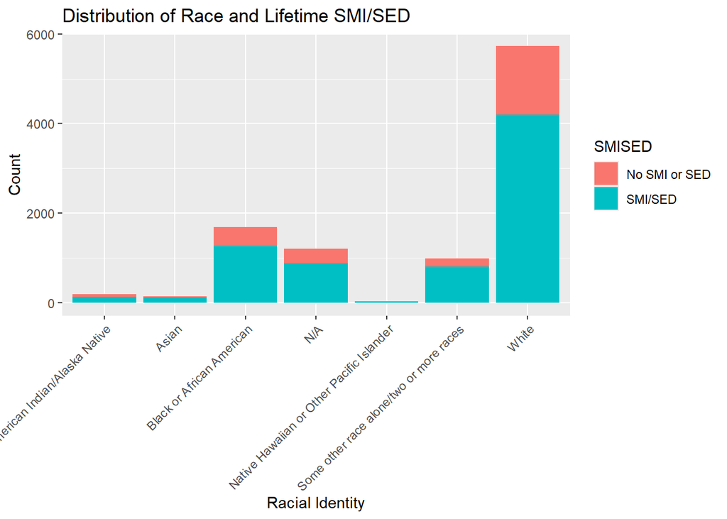

```r
completed_CLD_sample$RACE <- recode(completed_CLD_sample$RACE, `1` = "American Indian/Alaska Native", `2` = "Asian", `3` = "Black or African American", `4` = "Native Hawaiian or Other Pacific Islander", `5` = "White", `6` = "Some other race alone/two or more races",`-9` = "N/A")

completed_CLD_sample %>%
  ggplot() +
  geom_bar(aes(x = RACE, fill = SMISED))+
  theme(axis.text.x = element_text(angle = 45, hjust = 1))+
  xlab("Racial Identity") + ylab("Count") + ggtitle("Distribution of Race and Lifetime SMI/SED")
```

In figure 3, there are similar indications as to what datapoints may predict no SMI or SED. According to the figure, a smaller proportion of white-identifying clients were diagnosed with SMI/SED than black or bi-racial clients. In this way, racial identity may be a relatively strong predictor of development of SMI/SED.

# Unsupervised Learning

Let’s try hierarchical clustering as an unsupervised learning technique to examine the similarities across our data.

### Figure 4

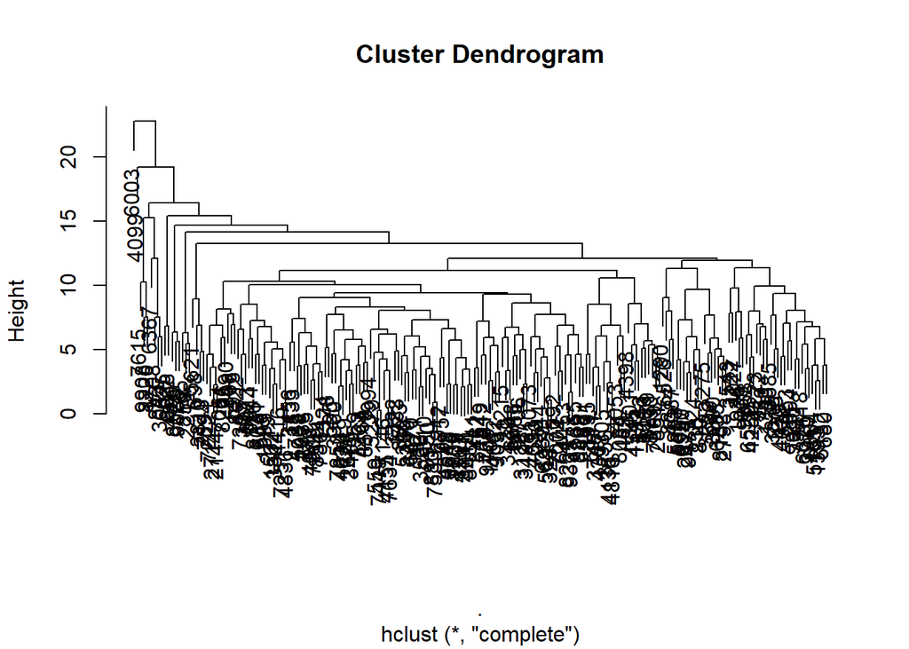

```r
# lets take a sample to simplify the figure
set.seed(77)
sample_2 <- sample(1:nrow(completed_CLD_sample),
                     size = 200)

dendrogram_sample <- completed_CLD_sample[sample_2, ]

dendrogram_sample$SMISED <- as.numeric(as.factor(dendrogram_sample$SMISED))
dendrogram_sample$AGE <- as.numeric(as.factor(dendrogram_sample$AGE))
dendrogram_sample$MH1 <- as.numeric(as.factor(dendrogram_sample$MH1))
dendrogram_sample$RACE <- as.numeric(as.factor(dendrogram_sample$RACE))

dendrogram_sample %>%
  select(-YEAR, -CASEID) %>%
  scale() %>%
  dist() %>%
  hclust() %>%
  plot()
```

Figure 4 above visually represents the hierarchical relationships between different data points, showing how similar or dissimilar they are to each other. In essence, the longer the branch connecting two data points on the dendrogram, the less similar they are to each other. Here, we see the cluster dendrogram for our sample of 200 respondents. Rather than telling us what particular relationship the sampled clients in the figure have, the dendrogram demonstrates the existence of similarities in the data and underscores the many complex combinations of demographic and clinical information in the data.

# Support Vector Machine

To predict severe mental health outcomes, I opted to first try a Support Vector Machine (SVM). A SVM is a supervised learning approach that is well suited for classification problems with high dimensionality such as the one at hand. In a SVM, all data points coordinates are refereed to as features in the n-dimensional space. In essence a SVM takes the data set and attempts to draw a line that subsets datapoints into two classes. This line, known as a “hyperplane” has the goal of placing all points of one class on one side (e.g. all SMI/SED individuals) and others (no SMI/SED) on the other side. While there could be a number of appropriate hyperplanes, SVM tries to find the one that best differentiates the two categories. This is done by calculating the line at which the distance between points in both classes is at its maximum. Below is the best fit SVM application for this data set.

```r
set.seed(1)
training_rows <- sample(1:nrow(completed_CLD_sample),
                        size = nrow(completed_CLD_sample)/2)

train_data <- completed_CLD_sample[training_rows, ]
test_data <- completed_CLD_sample[-training_rows, ]
```

```r
set.seed(77)
my_svm <- svm(as.factor(SMISED) ~. -YEAR -CASEID, data = train_data)

# data set too large to effectively tune

svm_predictions <- predict(my_svm, test_data)

# confusion matrix
table(svm_predictions, train_data$SMISED)
```

```
##
## svm_predictions No SMI or SED SMI/SED
##   No SMI or SED           106     343
##   SMI/SED                1183    3368
```

Here, I further split the sample into two subsets. One such subset was used to train the support vector machine and the other were used to predict from. Particular tuning of epsilon value (i.e., the width of a tolerance margin that controls precision/over fitting) and cost (i.e, how much the model is allowed to misclassify data points in order to achieve a wider margin between classes) was attempted, but due to the size of the dataset and time to compute, this was not possible. The above confusion matrix represents the accuracy of the chosen SVM. In all, the model predicted that a wide majority of clients suffered from SMI/SED. This is represented by the large number of false positives (23.66%) relative to the false negative rate (6.86%). The overall accuracy, however, was around 70%.

# Random Forest

Next, I compared the results of this SVM with those of a random forest. As opposed to the SVM, the random forest seeks to make prediction off of a collection of decision trees to make predictions

```r
set.seed(77)
random_f <- randomForest(as.factor(SMISED) ~ . -YEAR -CASEID, data = train_data)
rf_predictions <- predict(random_f, test_data)

# confusion matrix
table(rf_predictions, train_data$SMISED)
```

```
##
## rf_predictions  No SMI or SED SMI/SED
##   No SMI or SED           245     708
##   SMI/SED                1044    3003
```